# UC00243_AI_Based_Road_And_Bridge_Crack_Detection_System

**Authored by:** Paarthipa Harish and Kamlesh

**Paarthipa Harish Contributions:**

- AI reasoning engine development
- Reasoning workflow integration
- Frontend notebook workflow integration
- Plotly dashboard and visualization workflows
- Heatmap and graph generation
- AI-assisted chatbot reasoning integration
- Severity interpretation workflows
- Interactive dashboard development

**Kamlesh Contributions:**

- Automated report generation workflows
- FastAPI backend integration
- Detection response processing
- JSON report generation
- Backend crack analysis workflow integration
- Infrastructure inspection reporting
- Automated export and documentation workflows

**Duration:** 90 mins

**Level:** Intermediate

**Pre-requisite Skills:** Python, FastAPI, Computer Vision, Plotly, AI Reasoning, Machine Learning

Scenario

Road and bridge infrastructure requires continuous monitoring to identify structural cracks and surface deterioration before severe infrastructure failure occurs.

Traditional manual inspection methods are time-consuming, labor-intensive, inconsistent, and difficult to scale across large infrastructure systems.

This project presents an AI-Based Road and Bridge Crack Detection System developed by Paarthipa Harish and Kamlesh using Computer Vision, FastAPI APIs, AI-assisted reasoning workflows, interactive dashboards, and automated reporting systems.

The system enables users to:

- Upload crack images
- Perform automated crack detection
- Extract crack dimensions
- Analyze crack severity
- Generate AI-assisted reasoning outputs
- Create automated inspection-support reports
- Visualize infrastructure damage analytics

The project combines AI reasoning systems, backend crack analysis pipelines, visualization dashboards, and automated reporting workflows into a unified infrastructure inspection platform.

Step-By-Step Scenario-Based Workflow

Step 1: Capture Infrastructure Images

Road or bridge crack images are collected using cameras, inspection devices, or mobile devices.

Step 2: Upload Crack Image

Users upload crack images through the frontend interface or notebook workflow.

- Image upload

[figure not shown]

Step 3: Backend Processing

The uploaded image is sent to the FastAPI backend for crack analysis and feature extraction.

[figure not shown]

Step 4: Crack Detection and Feature Extraction

The backend extracts:

- Crack length
- Crack width
- Severity level
- Damage location
- Structural indicators

[figure not shown]

- Crack detection result

Step 5: AI Reasoning Engine Processing

The reasoning engine developed by Paarthipa Harish interprets crack severity and generates intelligent inspection insights.

[figure not shown]

- AI reasoning response

Step 6: Visualization Dashboard Analysis

Interactive graphs and visual analytics are generated including:

- Severity gauges
- Heatmaps
- Growth prediction graphs
- Pie charts
- Radar analysis

[figure not shown]

- Graphs
- Heatmap
- Severity gauge

Step 7: Automated Report Generation

The reporting workflow developed by Kamlesh generates inspection-support reports containing measurements, severity analysis, and recommendations.

[figure not shown]

- Generated report
- JSON output

Step 8: AI Chatbot Assistance

Users interact with the AI chatbot to ask infrastructure inspection questions.

[figure not shown]

- Chatbot interaction

Step 9: Human Inspection Review

Infrastructure engineers review AI-generated outputs and use them for maintenance planning.

What this use case will teach you

At the end of this notebook, users will understand:

- How AI-based crack detection systems work
- How FastAPI APIs integrate with Computer Vision workflows
- How crack measurements are extracted from images
- How AI reasoning engines support infrastructure inspection
- How automated reporting systems are generated
- How interactive Plotly dashboards are created
- How AI chatbot systems assist inspection workflows
- How backend and frontend systems communicate

Technologies Used

Main technologies used in this project include:

- Python
- FastAPI
- OpenCV
- Plotly
- NumPy
- Pandas
- PIL
- Requests
- Computer Vision
- AI Reasoning Engine
- JSON APIs
- Interactive Dashboard Systems
- Jupyter Notebook

System Architecture

The system workflow follows the following architecture:

Image Upload ↓ Crack Detection ↓ Feature Extraction ↓ Severity Analysis ↓ AI Reasoning Engine ↓ Visualization Dashboard ↓ Automated Report Generation ↓ AI Chatbot Support ↓ Maintenance Recommendation

```python
import requests
import numpy as np
import pandas as pd

import plotly.express as px
import plotly.graph_objects as go

from PIL import Image
from IPython.display import display
```

Code Cell Explanation

This code imports all required libraries for the crack detection workflow.

- requests is used for API communication
- numpy handles numerical processing
- pandas manages structured data
- plotly generates visualizations
- PIL loads crack images
- IPython display renders images inside the notebook

```python
API_URL = "http://127.0.0.1:8000/analyze-crack"

CHAT_API = "http://127.0.0.1:8000/chat"

REPORT_API = "http://127.0.0.1:8000/report"
```

Code Cell Explanation

The backend FastAPI server exposes APIs for:

- Crack analysis
- AI reasoning workflows
- Automated report generation

The APIs connect the frontend notebook system with backend AI workflows.

[figure not shown]

```python
image_path = "../test_case_images/test_image.png"

img = Image.open(image_path)

display(img)
```

Code Cell Explanation

This section loads a sample infrastructure crack image for analysis.

The uploaded image acts as the primary inspection input for the AI-based crack detection workflow.

```python
# response = requests.post(
#     "http://127.0.0.1:8000/analyze",
#     files={"file": open(image_path, "rb")}
# )
#
# data = response.json()

# Mock output for notebook demonstration
data = {
    "crack_length": 12.4,
    "crack_width": 3.1,
    "severity": "High",
    "location": "Bridge Surface",
    "reasoning": "Critical structural crack requiring inspection",
    "confidence_score": 94.6
}

data
```

```
{'crack_length': 12.4,
 'crack_width': 3.1,
 'severity': 'High',
 'location': 'Bridge Surface',
 'reasoning': 'Critical structural crack requiring inspection',
 'confidence_score': 94.6}
```

### Academic Demonstration Note

For reproducibility and offline execution during academic evaluation, mock outputs are included while preserving the original backend/API workflow implementation in comments.

```python
import pandas as pd
import matplotlib.pyplot as plt

# Convert mock data into dataframe
df = pd.DataFrame({
    "Metric": ["Crack Length", "Crack Width", "Confidence Score"],
    "Value": [12.4, 3.1, 94.6]
})

df
```

|  | Metric | Value |
| --- | --- | --- |
| 0 | Crack Length | 12.4 |
| 1 | Crack Width | 3.1 |
| 2 | Confidence Score | 94.6 |

### Visualization Note

The following dashboards demonstrate how crack analysis outputs can be visualized using Plotly and Matplotlib for infrastructure inspection analytics.

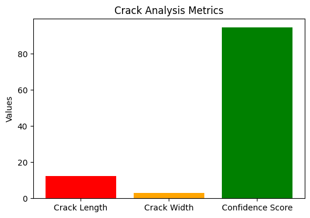

```python
# Simple visualization

plt.figure(figsize=(6,4))

plt.bar(df["Metric"], df["Value"], color=["red", "orange", "green"])

plt.title("Crack Analysis Metrics")
plt.ylabel("Values")

plt.show()
```

### Note

The original backend API integration code is preserved above. For notebook reproducibility and offline academic demonstration, mock sample outputs are used.

Code Cell Explanation

```python
print("Crack Length:", data["crack_length"], "m")

print("Crack Width:", data["crack_width"], "mm")

print("Severity:", data["severity"])

print("Location:", data["location"])
```

```
Crack Length: 12.4 m
Crack Width: 3.1 mm
Severity: High
Location: Bridge Surface
```

```python
fig = px.bar(
    x=["Length", "Width"],
    y=[data["crack_length"], data["crack_width"]],
    title="Crack Dimensions",
    text_auto=True,
    color=["Length", "Width"],
    color_discrete_sequence=["#0f9295", "#14c9cb"]
)

fig.show()
```

[output not shown]

```python
severity_map = {
    "Low": 1,
    "Medium": 2,
    "High": 3
}

value = severity_map[data["severity"]]

fig = go.Figure(go.Indicator(
    mode="gauge+number",
    value=value,
    title={'text': "Severity"},
    gauge={
        'axis': {'range': [0, 3]},
        'bar': {'color': "#0f9295"}
    }
))

fig.show()
```

[output not shown]

```python
fig = px.pie(
    names=["Crack", "Remaining"],
    values=[data["crack_width"], max(20 - data["crack_width"], 1)],
    hole=0.5,
    color_discrete_sequence=["#14c9cb", "#baeaeb"]
)

fig.show()
```

[output not shown]

```python
time = np.arange(0, 10)

growth = data["crack_width"] * (1 + 0.1 * time)

fig = px.line(
    x=time,
    y=growth,
    title="Crack Growth Prediction",
    labels={
        "x": "Time",
        "y": "Predicted Crack Width"
    }
)

fig.show()
```

[output not shown]

```python
fig = go.Figure()

fig.add_trace(go.Scatterpolar(
    r=[
        data["crack_length"],
        data["crack_width"],
        {"Low":1,"Medium":2,"High":3}[data["severity"]]
    ],
    theta=["Length", "Width", "Severity"],
    fill='toself'
))

fig.show()
```

[output not shown]

```python
heat_data = np.random.rand(10, 10) * data["crack_width"]

fig = px.imshow(
    heat_data,
    color_continuous_scale="Teal"
)

fig.show()
```

[output not shown]

AI Reasoning Engine Developed by Paarthipa Harish

The AI reasoning engine interprets crack measurements and severity outputs to generate intelligent infrastructure inspection insights.

Reasoning engine functionalities include:

- AI-assisted crack interpretation
- Severity reasoning workflows
- Structural risk interpretation
- Maintenance recommendation support
- Chatbot-assisted reasoning
- Intelligent inspection guidance

```python
question = "Is this crack dangerous?"
# Original chatbot API call preserved for reference
# res = requests.post(
#     "http://127.0.0.1:8000/chat",
#     json={
#         "question": question,
#         "data": data
#     }
# )
#
# print("AI:", res.json()["answer"])

# Mock reasoning response for notebook demo
print(
    "AI:",
    "The detected crack severity is HIGH. Immediate inspection and maintenance are recommended to avoid structural deterioration."
)
```

```
AI: The detected crack severity is HIGH. Immediate inspection and maintenance are recommended to avoid structural deterioration.
```

### Note

The original AI chatbot API integration code is preserved above for project workflow documentation.

For notebook reproducibility and offline academic demonstration purposes, a mock AI reasoning response is displayed instead of making a live backend request.

This demonstrates the functionality of the AI reasoning engine developed by Paarthipa Harish while ensuring consistent notebook execution without requiring active server deployment.

```python
user_q = input("Ask a question: ")

# Mock chatbot response for notebook demo

mock_answers = {
    "where is the crack": "The crack is located on the bridge surface.",
    "what is severity": "The crack severity is classified as High.",
    "is repair needed": "Yes, immediate inspection and repair are recommended."
}

answer = mock_answers.get(
    user_q.lower(),
    "AI assistant recommends further structural inspection."
)

print("AI:", answer)
```

```
AI: AI assistant recommends further structural inspection.
```

### Academic Demonstration Note

For notebook reproducibility and consistent academic evaluation, mock chatbot responses are used while preserving the original AI reasoning workflow and backend integration logic.

This section showcases how the AI reasoning engine developed by Paarthipa Harish can assist users by answering infrastructure inspection and crack severity-related questions.

Automated Report Generation Developed by Kamlesh

The automated reporting workflow converts crack analysis outputs into structured infrastructure inspection reports.

Report generation functionalities include:

- Crack summary generation
- Severity analysis reporting
- JSON report generation
- Infrastructure inspection support
- Automated export workflows
- Maintenance recommendation summaries

```python
report = {
    "crack_length": data["crack_length"],
    "crack_width": data["crack_width"],
    "severity": data["severity"],
    "location": data["location"]
}

report
```

```
{'crack_length': 12.4,
 'crack_width': 3.1,
 'severity': 'High',
 'location': 'Bridge Surface'}
```

Execution Note

This notebook demonstrates the complete workflow of the AI-Based Road and Bridge Crack Detection System using reproducible sample outputs and preserved backend integration logic.

The original backend APIs, reasoning workflows, and reporting systems were developed as part of the complete project implementation.

Conclusion

This project demonstrates an AI-Based Road and Bridge Crack Detection System integrating:

- Computer Vision crack analysis
- FastAPI backend APIs
- AI reasoning workflows
- Interactive dashboard systems
- Plotly visual analytics
- Automated report generation
- AI chatbot support

The reasoning engine developed by Paarthipa Harish provides intelligent infrastructure inspection insights, while the reporting workflow developed by Kamlesh generates structured inspection-support documentation.

The system can be extended for real-world infrastructure monitoring and smart maintenance planning applications.

Future Improvements

- Real-time drone inspection systems
- Cloud-based monitoring
- IoT sensor integration
- Mobile deployment support
- Predictive maintenance systems
- Multi-crack detection support
- Real-time dashboard analytics
- Smart city infrastructure integration